# Step 3: Post-Processing

Tyler J Burns

October 2, 2017

### The post-processing function:

This vignette covers what takes place following the generation of SCONE output detailed in TheSconeWorkflow.Rmd. The obvious step that needs to take place is the Scone generated columns being merged into the original input data. The user gets the option of log base 10 transforming q values, which is easier to visualize. The user also gets the option to run t-SNE on the data, such that said maps can be colored by SCONE generated values. In this case, t-SNE is run utilizing the Rtsne package, using the same markers that were used as input for the KNN. generation.

```r
library(Sconify)
library(ggplot2)
set.seed(12043)
final <- post.processing(scone.output = scone.output,
                         cell.data = combined,
                         input = input.markers)
```

[output not shown]

```r
combined # input data
```

```
## # A tibble: 10,000 x 51
##    `CD3(Cd110)Di` `CD3(Cd111)Di` `CD3(Cd112)Di` `CD235-61-7-15(In113)Di`
##             <dbl>          <dbl>          <dbl>                    <dbl>
##  1    0.086697628     2.55655055     1.65093670                0.5717975
##  2   -0.317043752     0.17677218    -1.17542705                0.2811703
##  3    0.364412214     0.13689811     1.35602613               -0.1061449
##  4    0.004806259    -0.09665493     0.20963892               -1.4465772
##  5   -0.228219645    -0.10838461    -0.21318524                0.8195761
##  6   -0.279749579    -0.35149480    -0.54900005                0.2709792
##  7   -0.211592636    -0.17895398    -0.07165329               -0.7098735
##  8    0.824610463    -0.02181934    -0.03550176                0.3672940
##  9   -0.183561781     0.11522096     0.11892369               -0.2309404
## 10   -0.227596717    -0.18770460    -0.16647946               -0.5095834
## # ... with 9,990 more rows, and 47 more variables: `CD3(Cd114)Di` <dbl>,
## #   `CD45(In115)Di` <dbl>, `CD19(Nd142)Di` <dbl>, `CD22(Nd143)Di` <dbl>,
## #   `IgD(Nd145)Di` <dbl>, `CD79b(Nd146)Di` <dbl>, `CD20(Sm147)Di` <dbl>,
## #   `CD34(Nd148)Di` <dbl>, `CD179a(Sm149)Di` <dbl>, `CD72(Eu151)Di` <dbl>,
## #   `IgM(Eu153)Di` <dbl>, `Kappa(Sm154)Di` <dbl>, `CD10(Gd156)Di` <dbl>,
## #   `Lambda(Gd157)Di` <dbl>, `CD24(Dy161)Di` <dbl>, `TdT(Dy163)Di` <dbl>,
## #   `Rag1(Dy164)Di` <dbl>, `PreBCR(Ho165)Di` <dbl>, `CD43(Er167)Di` <dbl>,
## #   `CD38(Er168)Di` <dbl>, `CD40(Er170)Di` <dbl>, `CD33(Yb173)Di` <dbl>,
## #   `HLA-DR(Yb174)Di` <dbl>, Time <dbl>, Cell_length <dbl>,
## #   `cPARP(La139)Di` <dbl>, `pPLCg2(Pr141)Di` <dbl>,
## #   `pSrc(Nd144)Di` <dbl>, `pSTAT5(Nd150)Di` <dbl>, `Ki67(Sm152)Di` <dbl>,
## #   `pErk12(Gd155)Di` <dbl>, `pSTAT3(Gd158)Di` <dbl>,
## #   `pAKT(Tb159)Di` <dbl>, `pBLNK(Gd160)Di` <dbl>, `pSyk(Dy162)Di` <dbl>,
## #   `tIkBa(Er166)Di` <dbl>, `pP38(Tm169)Di` <dbl>, `pBTK(Yb171)Di` <dbl>,
## #   `pS6(Yb172)Di` <dbl>, `pCrkL(Lu175)Di` <dbl>, `pCREB(Yb176)Di` <dbl>,
## #   `DNA1(Ir191)Di` <dbl>, `DNA2(Ir193)Di` <dbl>,
## #   `Viability1(Pt195)Di` <dbl>, `Viability2(Pt196)Di` <dbl>,
## #   wanderlust <dbl>, condition <chr>
```

```r
scone.output # scone-generated data
```

```
## # A tibble: 10,000 x 33
##    `pCrkL(Lu175)Di.IL7.qvalue` `pCREB(Yb176)Di.IL7.qvalue`
##                          <dbl>                       <dbl>
##  1                   0.9982854                   0.4681202
##  2                   0.9039395                   0.1019775
##  3                   0.8198289                   0.8562482
##  4                   0.9844948                   0.7115620
##  5                   0.9836674                   0.7567898
##  6                   0.9836674                   0.2974020
##  7                   0.9476343                   0.2115703
##  8                   0.9078531                   0.9281132
##  9                   0.9039395                   0.9233194
## 10                   0.9844948                   0.6685733
## # ... with 9,990 more rows, and 31 more variables:
## #   `pBTK(Yb171)Di.IL7.qvalue` <dbl>, `pS6(Yb172)Di.IL7.qvalue` <dbl>,
## #   `cPARP(La139)Di.IL7.qvalue` <dbl>, `pPLCg2(Pr141)Di.IL7.qvalue` <dbl>,
## #   `pSrc(Nd144)Di.IL7.qvalue` <dbl>, `Ki67(Sm152)Di.IL7.qvalue` <dbl>,
## #   `pErk12(Gd155)Di.IL7.qvalue` <dbl>,
## #   `pSTAT3(Gd158)Di.IL7.qvalue` <dbl>, `pAKT(Tb159)Di.IL7.qvalue` <dbl>,
## #   `pBLNK(Gd160)Di.IL7.qvalue` <dbl>, `pP38(Tm169)Di.IL7.qvalue` <dbl>,
## #   `pSTAT5(Nd150)Di.IL7.qvalue` <dbl>, `pSyk(Dy162)Di.IL7.qvalue` <dbl>,
## #   `tIkBa(Er166)Di.IL7.qvalue` <dbl>, `pCrkL(Lu175)Di.IL7.change` <dbl>,
## #   `pCREB(Yb176)Di.IL7.change` <dbl>, `pBTK(Yb171)Di.IL7.change` <dbl>,
## #   `pS6(Yb172)Di.IL7.change` <dbl>, `cPARP(La139)Di.IL7.change` <dbl>,
## #   `pPLCg2(Pr141)Di.IL7.change` <dbl>, `pSrc(Nd144)Di.IL7.change` <dbl>,
## #   `Ki67(Sm152)Di.IL7.change` <dbl>, `pErk12(Gd155)Di.IL7.change` <dbl>,
## #   `pSTAT3(Gd158)Di.IL7.change` <dbl>, `pAKT(Tb159)Di.IL7.change` <dbl>,
## #   `pBLNK(Gd160)Di.IL7.change` <dbl>, `pP38(Tm169)Di.IL7.change` <dbl>,
## #   `pSTAT5(Nd150)Di.IL7.change` <dbl>, `pSyk(Dy162)Di.IL7.change` <dbl>,
## #   `tIkBa(Er166)Di.IL7.change` <dbl>, IL7.fraction.cond.2 <dbl>
```

```r
final # the data after post-processing
```

```
## # A tibble: 10,000 x 86
##    `CD3(Cd110)Di` `CD3(Cd111)Di` `CD3(Cd112)Di` `CD235-61-7-15(In113)Di`
##             <dbl>          <dbl>          <dbl>                    <dbl>
##  1    0.086697628     2.55655055     1.65093670                0.5717975
##  2   -0.317043752     0.17677218    -1.17542705                0.2811703
##  3    0.364412214     0.13689811     1.35602613               -0.1061449
##  4    0.004806259    -0.09665493     0.20963892               -1.4465772
##  5   -0.228219645    -0.10838461    -0.21318524                0.8195761
##  6   -0.279749579    -0.35149480    -0.54900005                0.2709792
##  7   -0.211592636    -0.17895398    -0.07165329               -0.7098735
##  8    0.824610463    -0.02181934    -0.03550176                0.3672940
##  9   -0.183561781     0.11522096     0.11892369               -0.2309404
## 10   -0.227596717    -0.18770460    -0.16647946               -0.5095834
## # ... with 9,990 more rows, and 82 more variables: `CD3(Cd114)Di` <dbl>,
## #   `CD45(In115)Di` <dbl>, `CD19(Nd142)Di` <dbl>, `CD22(Nd143)Di` <dbl>,
## #   `IgD(Nd145)Di` <dbl>, `CD79b(Nd146)Di` <dbl>, `CD20(Sm147)Di` <dbl>,
## #   `CD34(Nd148)Di` <dbl>, `CD179a(Sm149)Di` <dbl>, `CD72(Eu151)Di` <dbl>,
## #   `IgM(Eu153)Di` <dbl>, `Kappa(Sm154)Di` <dbl>, `CD10(Gd156)Di` <dbl>,
## #   `Lambda(Gd157)Di` <dbl>, `CD24(Dy161)Di` <dbl>, `TdT(Dy163)Di` <dbl>,
## #   `Rag1(Dy164)Di` <dbl>, `PreBCR(Ho165)Di` <dbl>, `CD43(Er167)Di` <dbl>,
## #   `CD38(Er168)Di` <dbl>, `CD40(Er170)Di` <dbl>, `CD33(Yb173)Di` <dbl>,
## #   `HLA-DR(Yb174)Di` <dbl>, Time <dbl>, Cell_length <dbl>,
## #   `cPARP(La139)Di` <dbl>, `pPLCg2(Pr141)Di` <dbl>,
## #   `pSrc(Nd144)Di` <dbl>, `pSTAT5(Nd150)Di` <dbl>, `Ki67(Sm152)Di` <dbl>,
## #   `pErk12(Gd155)Di` <dbl>, `pSTAT3(Gd158)Di` <dbl>,
## #   `pAKT(Tb159)Di` <dbl>, `pBLNK(Gd160)Di` <dbl>, `pSyk(Dy162)Di` <dbl>,
## #   `tIkBa(Er166)Di` <dbl>, `pP38(Tm169)Di` <dbl>, `pBTK(Yb171)Di` <dbl>,
## #   `pS6(Yb172)Di` <dbl>, `pCrkL(Lu175)Di` <dbl>, `pCREB(Yb176)Di` <dbl>,
## #   `DNA1(Ir191)Di` <dbl>, `DNA2(Ir193)Di` <dbl>,
## #   `Viability1(Pt195)Di` <dbl>, `Viability2(Pt196)Di` <dbl>,
## #   wanderlust <dbl>, condition <dbl>, `pCrkL(Lu175)Di.IL7.change` <dbl>,
## #   `pCREB(Yb176)Di.IL7.change` <dbl>, `pBTK(Yb171)Di.IL7.change` <dbl>,
## #   `pS6(Yb172)Di.IL7.change` <dbl>, `cPARP(La139)Di.IL7.change` <dbl>,
## #   `pPLCg2(Pr141)Di.IL7.change` <dbl>, `pSrc(Nd144)Di.IL7.change` <dbl>,
## #   `Ki67(Sm152)Di.IL7.change` <dbl>, `pErk12(Gd155)Di.IL7.change` <dbl>,
## #   `pSTAT3(Gd158)Di.IL7.change` <dbl>, `pAKT(Tb159)Di.IL7.change` <dbl>,
## #   `pBLNK(Gd160)Di.IL7.change` <dbl>, `pP38(Tm169)Di.IL7.change` <dbl>,
## #   `pSTAT5(Nd150)Di.IL7.change` <dbl>, `pSyk(Dy162)Di.IL7.change` <dbl>,
## #   `tIkBa(Er166)Di.IL7.change` <dbl>, IL7.fraction.cond.2 <dbl>,
## #   `bh-SNE1` <dbl>, `bh-SNE2` <dbl>, `pCrkL(Lu175)Di.IL7.qvalue` <dbl>,
## #   `pCREB(Yb176)Di.IL7.qvalue` <dbl>, `pBTK(Yb171)Di.IL7.qvalue` <dbl>,
## #   `pS6(Yb172)Di.IL7.qvalue` <dbl>, `cPARP(La139)Di.IL7.qvalue` <dbl>,
## #   `pPLCg2(Pr141)Di.IL7.qvalue` <dbl>, `pSrc(Nd144)Di.IL7.qvalue` <dbl>,
## #   `Ki67(Sm152)Di.IL7.qvalue` <dbl>, `pErk12(Gd155)Di.IL7.qvalue` <dbl>,
## #   `pSTAT3(Gd158)Di.IL7.qvalue` <dbl>, `pAKT(Tb159)Di.IL7.qvalue` <dbl>,
## #   `pBLNK(Gd160)Di.IL7.qvalue` <dbl>, `pP38(Tm169)Di.IL7.qvalue` <dbl>,
## #   `pSTAT5(Nd150)Di.IL7.qvalue` <dbl>, `pSyk(Dy162)Di.IL7.qvalue` <dbl>,
## #   `tIkBa(Er166)Di.IL7.qvalue` <dbl>
```

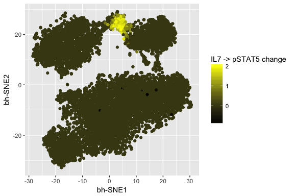

```r
# tSNE map shows highly responsive population of interest
qplot(final$`bh-SNE1`,
      final$`bh-SNE2`,
      color = final$`pSTAT5(Nd150)Di.IL7.change`,
      xlab = "bh-SNE1",
      ylab = "bh-SNE2") +
    labs(color = "IL7 -> pSTAT5 change") +
    scale_color_gradientn(colors = c("black", "yellow"))
```

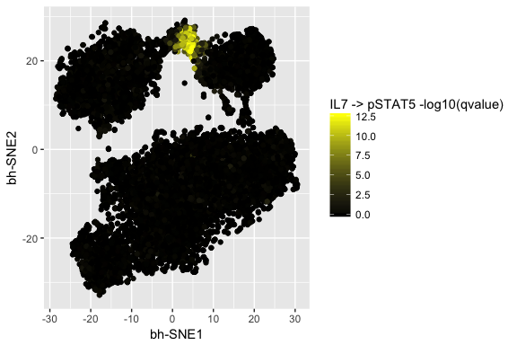

```r
# tSNE map now colored by q value
qplot(final$`bh-SNE1`,
      final$`bh-SNE2`,
      color = final$`pSTAT5(Nd150)Di.IL7.qvalue`,
      xlab = "bh-SNE1",
      ylab = "bh-SNE2") +
    labs(color = "IL7 -> pSTAT5 -log10(qvalue)") +
    scale_color_gradientn(colors = c("black", "yellow"))
```

For more extensive visualizations, you can output these results as an fcs file using the data.to.fcs wrapper I provided in the pre-processing functions. I would recommend this option, as Cytobank and FlowJo (among other tools) are more accessable than ggplot2 (although it is a great tool if you have learned it).

### From data matrix to fcs file:

After the full scone pipeline, one may want to convert the data back into fcs files to be read into fcs processing software, such as FlowJo or Cytobank. As such, I include a wrapper for FlowCore functionality, called data.to.fcs, that does just this. I also include the option to “un-transform” the data, if it has been asinh transformed with a co-factor of 5 initially. This is because Cytobank cannot (yet) effectively display asinh transformed data ranges, and it becomes tedious to switch the scale ranges within Cytobank. With data.to.fcs, you specify the name of the output file, and it gets saved to your working directory accordingly.

```
basal <- system.file('extdata',
    'Bendall et al Cell Sample C_basal.fcs',
    package = "Sconify")
basal <- fcs.to.tibble(basal, transform = "asinh")
data.to.fcs(basal, "basal.output.FCS", untransform = TRUE)
```